# Hierarchical Cluster Analysis for Tax Data

# Synopsis

In this report we aim to find out the proper way to detect outliers in tax data, especially which type of data to use in the analysis. Three different approaches are explored: Hierarchical cluster based only on original data, Hierarchical cluster based only on ratio data and Hierarchical cluster based only on all data. Since no labels in the dataset are avalible, the performance of this analysis is to be evaluated by hand.

# Preprocessing

1.Remove all the “DIV/0!” with “0”.

2.Copy and paste spacial with only values to another worksheet.

# Load data into workspace

```r
library(xlsx)
library(lattice)

## set word directory
setwd("/Users/xiangjiang/Documents/Tax/data/nashuipinggushuju/Chu Bu Zheng Li Shu Ju/qiyesuodeshuipeibishuju/")

## read data
data <- read.xlsx("08-09peibishuju.xls", sheetName = "Sheet2")

## remove irrelevant attributes
data[c("纳税人识别号", "所属年度", "纳税人名称.1", "纳税人识别号.1",
    "所属时期")] <- list(NULL)

## summary of data
summary(data)
```

```
##                         纳税人名称  销售.营业.收入        营业成本
##  武汉东尼文化传播有限公司    :  2   Min.   :       0   Min.   :       0
##  武汉信文科技有限公司        :  2   1st Qu.:       0   1st Qu.:       0
##  武汉欣网创业科技开发有限公司:  2   Median :   66342   Median :     404
##  武汉联宇技术股份有限公司    :  2   Mean   : 1825048   Mean   :  818787
##  武汉蓝筹科技有限公司        :  2   3rd Qu.: 1072090   3rd Qu.:  516694
##  武汉适普软件有限公司        :  2   Max.   :33243472   Max.   :21763076
##  (Other)                     :256
##  营业税金及附加       销售费用          管理费用           财务费用
##  Min.   :      0   Min.   :      0   Min.   :   -8238   Min.   :-2095593
##  1st Qu.:      0   1st Qu.:      0   1st Qu.:   10952   1st Qu.:    -786
##  Median :    925   Median :      0   Median :  167762   Median :       0
##  Mean   :  49901   Mean   : 230820   Mean   :  779259   Mean   :   19413
##  3rd Qu.:  29336   3rd Qu.:  66243   3rd Qu.:  789673   3rd Qu.:      74
##  Max.   :1823625   Max.   :7999472   Max.   :25340733   Max.   : 6472155
##
##     营业利润            利润总额         纳税调整后所得
##  Min.   :-26305537   Min.   :-26305537   Min.   :-7121308
##  1st Qu.:  -252986   1st Qu.:  -193393   1st Qu.: -178207
##  Median :   -33044   Median :   -26785   Median :  -19421
##  Mean   :   -91999   Mean   :    40481   Mean   :  116358
##  3rd Qu.:      -95   3rd Qu.:        0   3rd Qu.:       0
##  Max.   : 21683929   Max.   : 24931466   Max.   :24974787
##
##   应纳税所得额           税率       应纳所得税额        应纳税额
##  Min.   :       0   Min.   :0.25   Min.   :      0   Min.   :      0
##  1st Qu.:       0   1st Qu.:0.25   1st Qu.:      0   1st Qu.:      0
##  Median :       0   Median :0.25   Median :      0   Median :      0
##  Mean   :  312654   Mean   :0.25   Mean   :  78163   Mean   :  23522
##  3rd Qu.:       0   3rd Qu.:0.25   3rd Qu.:      0   3rd Qu.:      0
##  Max.   :24974787   Max.   :0.25   Max.   :6243697   Max.   :2493976
##
##  实际应纳所得税额  销售.营业.收入.1     营业成本.1       营业税金及附加.1
##  Min.   :      0   Min.   :       0   Min.   :       0   Min.   :-187572
##  1st Qu.:      0   1st Qu.:       0   1st Qu.:       0   1st Qu.:      0
##  Median :      0   Median :  118549   Median :    9825   Median :   1221
##  Mean   :  23522   Mean   : 2322165   Mean   : 1050660   Mean   :  64420
##  3rd Qu.:      0   3rd Qu.: 1553107   3rd Qu.:  585735   3rd Qu.:  33167
##  Max.   :2493976   Max.   :35801173   Max.   :19222366   Max.   :1555878
##
```

[output cut: 49 more lines]

```
##  Min.   : 0.000   Min.   :-2.585   Min.   :-141.23
##  1st Qu.: 0.000   1st Qu.: 0.000   1st Qu.:   0.00
##  Median : 0.000   Median : 0.000   Median :   0.00
##  Mean   : 0.109   Mean   : 0.065   Mean   :  -0.44
##  3rd Qu.: 0.000   3rd Qu.: 0.000   3rd Qu.:   0.79
##  Max.   :28.206   Max.   :24.494   Max.   :  30.27
##
##  营业收入与营业成本变动率配比分析 成本与利润配比
##  Min.   :-113.1                   Min.   :-334.7
##  1st Qu.:  -0.1                   1st Qu.:   0.0
##  Median :   0.0                   Median :   0.0
##  Mean   :   3.0                   Mean   :  -1.5
##  3rd Qu.:   0.2                   3rd Qu.:   0.0
##  Max.   : 921.5                   Max.   : 254.7
##
```

# Hierarchical cluster based only on original data

Here original data refers to data without ratio.

```r
data_orig <- data[2:29]

## computes and returns the distance matrix computed by using the specified
## distance measure to compute the distances between the rows of a data
## matrix
d <- dist(as.matrix(data_orig))

## apply hirarchical clustering
hc <- hclust(d)

pdf("Hierarchical cluster based only on original data.pdf", width = 50, height = 50)
## plot the dendrogram
plot(hc, main = "Hierarchical cluster based only on original data")
dev.off()
```

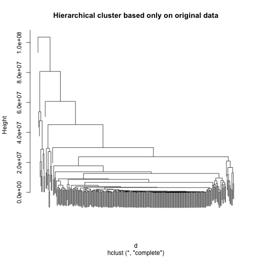

```r
plot(hc, labels = FALSE, main = "Hierarchical cluster based only on original data")
```

```r
print("Please find detail in .pdf file")
```

```
## [1] "Please find detail in .pdf file"
```

Distribution for different number of clusters are (ranging from 2 to 15 clusters):

```r
counts = sapply(2:15, function(ncl) table(cutree(hc, ncl)))
names(counts) = 2:15
counts
```

```
## $`2`
##
##   1   2
## 267   1
##
## $`3`
##
##   1   2   3
## 258   9   1
##
## $`4`
##
##   1   2   3   4
## 257   9   1   1
##
## $`5`
##
##   1   2   3   4   5
## 257   8   1   1   1
##
## $`6`
##
##   1   2   3   4   5   6
## 257   7   1   1   1   1
##
## $`7`
##
##   1   2   3   4   5   6   7
## 248   9   7   1   1   1   1
##
## $`8`
##
##   1   2   3   4   5   6   7   8
## 247   9   7   1   1   1   1   1
##
## $`9`
##
##   1   2   3   4   5   6   7   8   9
## 247   7   7   1   1   1   2   1   1
##
```

[output cut: 14 more lines]

```
##
## $`13`
##
##   1   2   3   4   5   6   7   8   9  10  11  12  13
## 236   3   1  11   4   1   4   1   2   1   2   1   1
##
## $`14`
##
##   1   2   3   4   5   6   7   8   9  10  11  12  13  14
## 236   3   1  10   4   1   4   1   1   2   1   2   1   1
##
## $`15`
##
##   1   2   3   4   5   6   7   8   9  10  11  12  13  14  15
## 236   3   1  10   4   1   1   1   3   1   2   1   2   1   1
```

For each cluster, the members are:

```r
## we pass the cutree function the cluster object and the number of clusters
## we're interested in Cuts a tree, e.g., as resulting from hclust, into
## several groups either by specifying the desired number(s) of groups or the
## cut height(s).

for (numClusters in c(2:15)) {
    print("===============================")
    print("When number of clusters are:")
    print(numClusters)
    mCluster = cutree(hc, numClusters)

    for (memCluster in c(1:numClusters)) {
        print("members of cluster ")
        print(memCluster)

        print(which(mCluster == memCluster))
        # print('Scatter plot for different observations are:')
        # print(splom(~data_orig,groups=mCluster,auto.key=TRUE))
    }
}
```

```
## [1] "==============================="
## [1] "When number of clusters are:"
## [1] 2
## [1] "members of cluster "
## [1] 1
##   [1]   1   2   3   4   5   6   7   8   9  10  11  12  13  14  15  16  17
##  [18]  18  19  20  21  22  23  24  25  26  27  28  29  30  31  32  33  34
##  [35]  35  36  37  38  39  40  41  42  43  44  45  46  47  48  49  50  51
##  [52]  52  53  54  55  56  57  58  59  60  61  62  63  64  65  66  67  68
##  [69]  69  70  71  72  73  74  75  76  77  78  79  80  81  82  83  84  85
##  [86]  86  87  88  89  90  91  92  93  94  95  96  97  98  99 100 101 102
## [103] 103 104 105 106 107 108 109 110 111 112 113 114 115 116 117 118 119
## [120] 120 121 122 123 124 125 126 127 128 129 130 131 132 133 134 135 136
## [137] 137 138 139 140 141 142 143 144 145 146 147 148 149 150 151 152 153
## [154] 154 155 156 157 158 159 160 161 162 163 164 165 166 167 168 169 170
```

[output cut: 582 more lines]

# Hierarchical cluster based only on ratio data

Here ratio data refers to data computed with formulars in Excel.

```r
data_ratio <- data[30:44]

## computes and returns the distance matrix computed by using the specified
## distance measure to compute the distances between the rows of a data
## matrix
d <- dist(as.matrix(data_ratio))

## apply hirarchical clustering
hc <- hclust(d)

pdf("Hierarchical cluster based only on ratio data.pdf", width = 50, height = 50)
## plot the dendrogram
plot(hc, main = "Hierarchical cluster based only on ratio data")
dev.off()
```

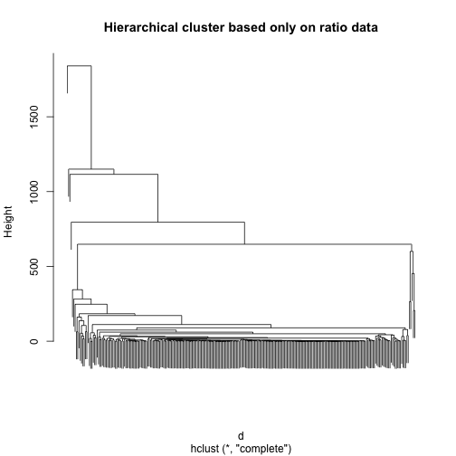

```r
plot(hc, labels = FALSE, main = "Hierarchical cluster based only on ratio data")
```

```r
print("Please find detail in .pdf file")
```

```
## [1] "Please find detail in .pdf file"
```

For each cluster, the members are:

```r
## we pass the cutree function the cluster object and the number of clusters
## we're interested in Cuts a tree, e.g., as resulting from hclust, into
## several groups either by specifying the desired number(s) of groups or the
## cut height(s).

for (numClusters in c(2:15)) {
    print("===============================")
    print("When number of clusters are:")
    print(numClusters)
    mCluster = cutree(hc, numClusters)

    for (memCluster in c(1:numClusters)) {
        print("members of cluster ")
        print(memCluster)

        print(which(mCluster == memCluster))
        # print('Scatter plot for different observations are:')
        # print(splom(~data_ratio,groups=mCluster,auto.key=TRUE))
    }
}
```

```
## [1] "==============================="
## [1] "When number of clusters are:"
## [1] 2
## [1] "members of cluster "
## [1] 1
##   [1]   1   2   3   4   5   6   7   8   9  10  11  12  13  14  15  16  17
##  [18]  18  19  20  21  22  23  24  25  26  27  28  29  30  31  32  33  34
##  [35]  35  36  37  38  39  40  41  42  43  44  45  46  47  48  49  50  51
##  [52]  52  53  54  55  56  57  58  59  60  61  62  63  64  65  66  67  68
##  [69]  69  70  71  72  73  74  75  76  77  78  79  80  81  82  83  84  85
##  [86]  86  87  88  89  90  91  92  93  94  95  96  97  98  99 100 101 102
## [103] 103 104 105 106 107 108 109 110 111 112 113 114 115 116 117 118 119
## [120] 120 121 122 123 124 125 126 127 128 129 130 131 132 133 135 136 137
## [137] 138 139 140 141 142 143 144 145 146 147 148 149 150 151 152 153 154
## [154] 155 156 157 158 159 160 161 162 163 164 165 166 167 168 169 170 171
```

[output cut: 592 more lines]

# Hierarchical cluster based on all data

Here all data refers to the original data as well as ratio data.

```r
data_all <- data[2:44]

## computes and returns the distance matrix computed by using the specified
## distance measure to compute the distances between the rows of a data
## matrix
d <- dist(as.matrix(data_all))

## apply hirarchical clustering
hc <- hclust(d)

pdf("Hierarchical cluster based on all data.pdf", width = 50, height = 50)
## plot the dendrogram
plot(hc, main = "Hierarchical cluster based on all data")
dev.off()
```

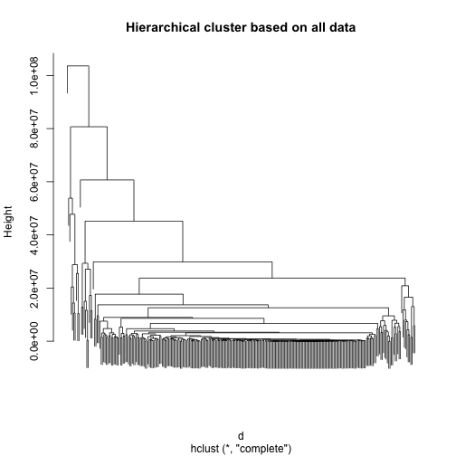

```r
plot(hc, labels = FALSE, main = "Hierarchical cluster based on all data")
```

```r
print("Please find detail in .pdf file")
```

```
## [1] "Please find detail in .pdf file"
```

For each cluster, the members are:

```r
## we pass the cutree function the cluster object and the number of clusters
## we're interested in Cuts a tree, e.g., as resulting from hclust, into
## several groups either by specifying the desired number(s) of groups or the
## cut height(s).

for (numClusters in c(2:15)) {
    print("===============================")
    print("When number of clusters are:")
    print(numClusters)
    mCluster = cutree(hc, numClusters)

    for (memCluster in c(1:numClusters)) {
        print("members of cluster ")
        print(memCluster)

        print(which(mCluster == memCluster))
        # print('Scatter plot for different observations are:')
        # print(splom(~data_all,groups=mCluster,auto.key=TRUE))
    }
}
```

```
## [1] "==============================="
## [1] "When number of clusters are:"
## [1] 2
## [1] "members of cluster "
## [1] 1
##   [1]   1   2   3   4   5   6   7   8   9  10  11  12  13  14  15  16  17
##  [18]  18  19  20  21  22  23  24  25  26  27  28  29  30  31  32  33  34
##  [35]  35  36  37  38  39  40  41  42  43  44  45  46  47  48  49  50  51
##  [52]  52  53  54  55  56  57  58  59  60  61  62  63  64  65  66  67  68
##  [69]  69  70  71  72  73  74  75  76  77  78  79  80  81  82  83  84  85
##  [86]  86  87  88  89  90  91  92  93  94  95  96  97  98  99 100 101 102
## [103] 103 104 105 106 107 108 109 110 111 112 113 114 115 116 117 118 119
## [120] 120 121 122 123 124 125 126 127 128 129 130 131 132 133 134 135 136
## [137] 137 138 139 140 141 142 143 144 145 146 147 148 149 150 151 152 153
## [154] 154 155 156 157 158 159 160 161 162 163 164 165 166 167 168 169 170
```

[output cut: 582 more lines]